# Status Study Report

```r
# prolific codes in surveys were not properly assigned, so manually replace them
participant_code_replacements <- function(x, y) {
  # x is the prolific ID that we use to replace participant codes
  # y is the given participant code
  case_when(
    x == '56e130548b1c33000a388671' ~ 'VATZ46',
    x == '6287f4819c5fc8c4d48cc885' ~ 'AVX9QE',
    x == '601d69a993d94008fb2b25dc' ~ 'YWTGUB',
    x == '650464007006929ee0cd9695' ~ 'ZWTG94',
    x == '614ce6a7a33bac955957f7a6' ~ 'TPZZQA',
    x == '6317511c1dd0acb82cf4b131' ~ 'VQWK3M',
    x == '5e3ae8e5ebfb032f9058ef33' ~ 'KB39HV',
    x == '6554d0515dc2a90a0f6b3ae3' ~ 'VNPHMU',
    x == '5ec59e86c9569f5e8000717b' ~ 'ZN3EYY',
    x == '5ee834d45f0f48129a79b683' ~ 'UGED4M',
    .default = y
  ) %>% return()
}
# drop these participant codes -- clarify _why_ with Austin
participant_code_drops <- c('a43n36','a6punv','84z39x','9eemkf','7wgznu','xx43nc')

# affective numeric values
numeric_affect <- function(x) case_when(
        x == "Very slightly or not at all" ~ 0,
        x == "A little" ~ 1,
        x == "Moderately" ~ 2,
        x == "Quite a bit" ~ 3,
        x == "Extremely" ~ 4,
        .default = NA)
calculate_affect <- function(x, affect_cols) {
  # x : data frame/tibble
  # affect_cols : list of characters denoting which columns to use

  x %>%
    select(paste0('panas_', affect_cols)) %>%
    rowSums(na.rm = TRUE) %>%
    return()
}

get_state_names <- function(x) {
  case_when(x == "AL" ~ "Alabama",
            x == "AK" ~ "Alaska",
            x == "AZ" ~ "Arizona",
            x == "AR" ~ "Arkansas",
            x == "CA" ~ "California",
            x == "CO" ~ "Colorado",
            x == "CT" ~ "Connecticut",
            x == "DE" ~ "Delaware",
            x == "FL" ~ "Florida",
            x == "GA" ~ "Georgia",
            x == "HI" ~ "Hawaii",
            x == "ID" ~ "Idaho",
            x == "IL" ~ "Illinois",
            x == "IN" ~ "Indiana",
            x == "IA" ~ "Iowa",
            x == "KS" ~ "Kansas",
            x == "KY" ~ "Kentucky",
            x == "LA" ~ "Louisiana",
            x == "ME" ~ "Maine",
            x == "MD" ~ "Maryland",
            x == "MA" ~ "Massachusetts",
            x == "MI" ~ "Michigan",
            x == "MN" ~ "Minnesota",
            x == "MS" ~ "Mississippi",
            x == "MO" ~ "Missouri",
            x == "MT" ~ "Montana",
            x == "NE" ~ "Nebraska",
            x == "NV" ~ "Nevada",
            x == "NH" ~ "New Hampshire",
            x == "NJ" ~ "New Jersey",
            x == "NM" ~ "New Mexico",
            x == "NY" ~ "New York",
            x == "NC" ~ "North Carolina",
            x == "ND" ~ "North Dakota",
            x == "OH" ~ "Ohio",
            x == "OK" ~ "Oklahoma",
            x == "OR" ~ "Oregon",
            x == "PA" ~ "Pennsylvania",
            x == "RI" ~ "Rhode Island",
            x == "SC" ~ "South Carolina",
            x == "SD" ~ "South Dakota",
            x == "TN" ~ "Tennessee",
            x == "TX" ~ "Texas",
            x == "UT" ~ "Utah",
            x == "VT" ~ "Vermont",
            x == "VA" ~ "Virginia",
            x == "WA" ~ "Washington",
            x == "WV" ~ "West Virginia",
            x == "WI" ~ "Wisconsin",
            x == "WY" ~ "Wyoming",
            x == "DC" ~  "District of Columbia",
            x == "PR" ~  "Puerto Rico") %>%
    return()
}
```

# Notes for Austin

- Why do we drop the following codes? `'a43n36','a6punv','84z39x','9eemkf','7wgznu','xx43nc'`
- Survey completion time: we were using `Duration (in seconds)_pre + Duration (in seconds)_post` to calculate survey completion time, but we should be using `intake` and `pretreatment` survey completion times
- Gold star $n$: 835
- There are three duplicate `participant_code`s in the `posttreat` survey

# Attrition

## Attrition through full study

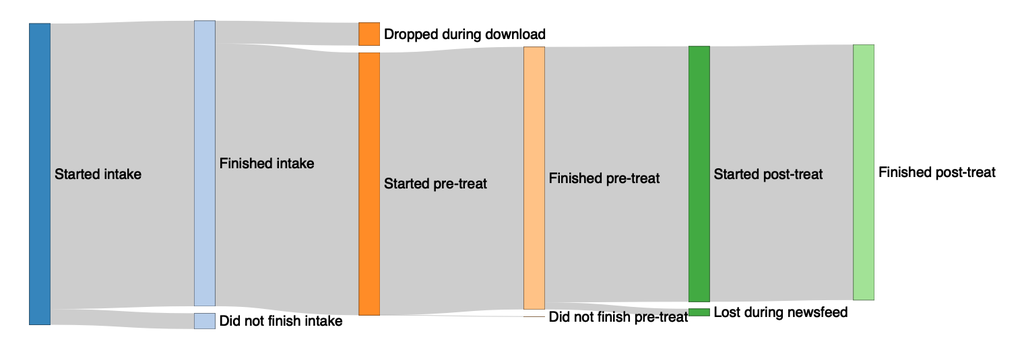

```r
# sankey diagram should have columns x, node, next_x, next_node
nodes <- tribble(
  ~node, ~stage,
  'Started intake', 1,
  'Finished intake', 2,
  'Did not finish intake', 2,
  'Dropped during download', 3,
  'Started pre-treat' , 3,
  'Finished pre-treat' , 4,
  'Did not finish pre-treat' , 4,
  'Started post-treat' , 5,
  'Lost during newsfeed', 5,
  'Finished post-treat', 6
  ) %>%
  rownames_to_column(var = 'node_index') %>%
  mutate(node_index = as.numeric(node_index) - 1) %>%
  mutate(stage = as.character(stage))

sankey_df <- tribble(
  ~'start', ~'end', ~'n',
  # 'Started intake', NA, total_n,
  'Started intake', 'Finished intake', intake_completes,
  'Started intake', 'Did not finish intake', total_n - intake_completes,
  'Finished intake', 'Dropped during download', attrit_intake_pretreat,
  'Finished intake', 'Started pre-treat', pretreat_n,
  'Started pre-treat', 'Finished pre-treat', pretreat_completes,
  'Started pre-treat', 'Did not finish pre-treat', pretreat_n - pretreat_completes,
  'Finished pre-treat', 'Started post-treat', posttreat_n,
  'Finished pre-treat', 'Lost during newsfeed', pretreat_completes - posttreat_n,
  'Started post-treat', 'Finished post-treat', posttreat_completes,
  # 'Finished post-treat', NA, NA
) %>%
  left_join(nodes, by = c('start' = 'node')) %>%
  rename('start_index' = 'node_index') %>%
  left_join(nodes, by = c('end' = 'node')) %>%
  rename('end_index' = 'node_index'
  )

sankey_plot <- networkD3::sankeyNetwork(
  Links = sankey_df,
  Nodes = nodes,
  Source = "start_index",
  Target = "end_index",
  Value = "n",
  units = "TWh",
  NodeID = 'node',
  NodeGroup = 'stage',
  fontSize = 20,
  nodeWidth = 30,
  sinksRight = FALSE
)


saveNetwork(sankey_plot, "./sn1.html")
webshot::install_phantomjs()
webshot("sn1.html", "sn1.png", vwidth = 1500, vheight = 500)
```

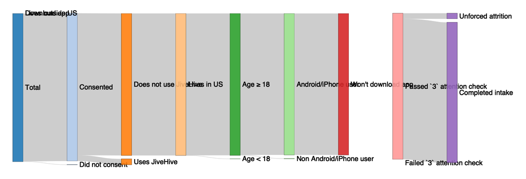

```r
n_consented <- intake %>% filter(Consent != 'No, I do NOT consent') %>% nrow()
n_does_not_use_jivehive <- intake %>%
  filter(platforms_jive != 'A lot') %>%
  filter(platforms_jive != 'Some') %>%
  nrow()
n_lives_in_us <- intake %>%
  filter(state != 'I do not reside in the United States') %>%
  nrow()
n_age_gr_18 <- intake %>%
  filter(age >= 18) %>%
  nrow()
n_android_iphone_user <- intake %>%
  filter(device != 'Something else') %>%
  nrow()
n_will_download_app <- intake %>%
  filter(download_apple != 'No, I am NOT') %>%
  filter(download_android != 'No, I am NOT') %>%
  nrow()
n_passed_3_att_check <- intake %>%
  filter(!is.na(screen_image)) %>%
  filter(screen_image == 3) %>%
  nrow()


intake_drops_nodes <- tribble(
  ~node, ~ stage,
  "Total", 1,
  "Consented", 2,
  "Did not consent", 2,
  "Does not use JiveHive", 3,
  "Uses JiveHive", 3,
  "Lives in US", 4,
  "Lives outside US", 4,
  "Age ≥ 18", 5,
  "Age < 18", 5,
  "Android/iPhone user", 6,
  "Non Android/iPhone user", 6,
  "Download app", 7,
  "Won't download app", 7,
  "Passed `3` attention check", 8,
  "Failed `3` attention check", 8,
  "Unforced attrition", 9,
  "Completed intake", 9
) %>%
  rownames_to_column(var = 'node_index') %>%
  mutate(node_index = as.numeric(node_index) - 1) %>%
  mutate(stage = as.character(stage))
intake_drops_df <- tribble(
  ~'start', ~'end', ~'n',
  'Total', 'Consented', n_consented,
  'Total', 'Did not consent', total_n - n_consented,
  'Consented', 'Does not use JiveHive', n_does_not_use_jivehive,
  'Consented', 'Uses JiveHive', n_consented - n_does_not_use_jivehive,
  'Does not use JiveHive', 'Lives in US', n_lives_in_us,
  'Does not use JiveHive', 'Lives outside US', n_does_not_use_jivehive - n_lives_in_us,
  'Lives in US', 'Age ≥ 18', n_age_gr_18,
  'Lives in US', 'Age < 18', n_lives_in_us - n_age_gr_18,
  'Age ≥ 18', 'Android/iPhone user', n_android_iphone_user,
  'Age ≥ 18', 'Non Android/iPhone user', n_age_gr_18 - n_android_iphone_user,
  'Android/iPhone user', 'Download app', n_will_download_app,
  'Android/iPhone user', 'Won\'t download app', n_android_iphone_user - n_will_download_app,
  'Download app', 'Passed `3` attention check', n_passed_3_att_check,
  'Download app', 'Failed `3` attention check', n_will_download_app - n_passed_3_att_check,
  'Passed `3` attention check', 'Unforced attrition', total_n - intake_completes - forced_attrit,
  'Passed `3` attention check', 'Completed intake', intake_completes
) %>%
  left_join(intake_drops_nodes, by = c('start' = 'node')) %>%
  rename('start_index' = 'node_index') %>%
  left_join(intake_drops_nodes, by = c('end' = 'node')) %>%
  rename('end_index' = 'node_index'
  )


sankey_plot2 <- networkD3::sankeyNetwork(
  Links = intake_drops_df,
  Nodes = intake_drops_nodes,
  Source = "start_index",
  Target = "end_index",
  Value = "n",
  units = "TWh",
  NodeID = 'node',
  NodeGroup = 'stage',
  fontSize = 20,
  nodeWidth = 30,
  sinksRight = FALSE
)


saveNetwork(sankey_plot2, "./sn2.html")
webshot::install_phantomjs()
webshot("sn2.html", "sn2.png", vwidth = 1500, vheight = 500)
```

```r
intake_new$finished_intake <- !is.na(intake_new$participant_code)
pretreat_new$finished_pretreat <- !is.na(pretreat_new$`Q111_Page Submit`)
pretreat_new$finished_newsfeed <- (pretreat_new$participant_code %in% posttreat_new$participant_code)
posttreat_new$finished_posttreat <- posttreat_new$Progress >= 93

demog_cols <- c('pid3', 'ideo7', 'race_new', 'device', 'new_educ', 'social_media_high', 'platforms_fb', 'platforms_insta', 'platforms_tiktok', 'platforms_x', 'platforms_truth')
pretreat_cols <- c('pre_ih_binary', 'extremity_pre', 'pre_policy_imm_binary', 'pre_policy_gc_binary', 'political_interest')

pretreat_demogs <- pretreat_new %>%
  left_join(intake_new %>% select(c(demog_cols, 'participant_code')), by = 'participant_code')
posttreat_pretreat_demogs <- posttreat_new %>%
  left_join(pretreat_demogs %>%
              select(c(demog_cols, pretreat_cols, 'participant_code')),
            by = 'participant_code')
predict_missing <- function(attrit_df, outcome, covariate) {
  df <- attrit_df %>%
    select(!!as.symbol(outcome), !!as.symbol(covariate)) %>%
    drop_na()
  if((df[[covariate]] %>% unique() %>% length()) > 2){
    df <- df %>%
      mutate_at(.funs = as.factor, .vars = c(covariate))

    ref <- levels(df[[covariate]])[1]
  } else {
    ref <- NA
  }

  glm_result <-
    glm(
      formula = paste0(outcome, '~', covariate),
      family = 'binomial',
      data = df
    )

  return_df <- glm_result %>%
    summary() %>%
    .$coefficients %>%
    as.data.frame() %>%
    mutate(outcome = outcome) %>%
    mutate(reference = ref) %>%
    rownames_to_column()

  return(return_df)
}
attrit_regs <- predict_missing(intake_new, 'finished_intake', 'pid3') %>%
bind_rows(predict_missing(intake_new, 'finished_intake', 'ideo7')) %>%
bind_rows(predict_missing(intake_new, 'finished_intake', 'race_new')) %>%
bind_rows(predict_missing(intake_new, 'finished_intake', 'device')) %>%
bind_rows(predict_missing(intake_new, 'finished_intake', 'new_educ')) %>%
bind_rows(predict_missing(intake_new, 'finished_intake', 'social_media_high')) %>%
bind_rows(predict_missing(intake_new, 'finished_intake', 'platforms_fb')) %>%
bind_rows(predict_missing(intake_new, 'finished_intake', 'platforms_insta')) %>%
bind_rows(predict_missing(intake_new, 'finished_intake', 'platforms_tiktok')) %>%
bind_rows(predict_missing(intake_new, 'finished_intake', 'platforms_x')) %>%
bind_rows(predict_missing(intake_new, 'finished_intake', 'platforms_truth')) %>%
bind_rows(predict_missing(pretreat_demogs, 'finished_pretreat', 'pid3')) %>%
bind_rows(predict_missing(pretreat_demogs, 'finished_pretreat', 'ideo7')) %>%
bind_rows(predict_missing(pretreat_demogs, 'finished_pretreat', 'race_new')) %>%
bind_rows(predict_missing(pretreat_demogs, 'finished_pretreat', 'device')) %>%
bind_rows(predict_missing(pretreat_demogs, 'finished_pretreat', 'new_educ')) %>%
bind_rows(predict_missing(pretreat_demogs, 'finished_pretreat', 'social_media_high')) %>%
bind_rows(predict_missing(pretreat_demogs, 'finished_pretreat', 'platforms_fb')) %>%
bind_rows(predict_missing(pretreat_demogs, 'finished_pretreat', 'platforms_insta')) %>%
bind_rows(predict_missing(pretreat_demogs, 'finished_pretreat', 'platforms_tiktok')) %>%
bind_rows(predict_missing(pretreat_demogs, 'finished_pretreat', 'platforms_x')) %>%
bind_rows(predict_missing(pretreat_demogs, 'finished_pretreat', 'platforms_truth')) %>%
bind_rows(predict_missing(pretreat_demogs, 'finished_newsfeed', 'pid3')) %>%
bind_rows(predict_missing(pretreat_demogs, 'finished_newsfeed', 'ideo7')) %>%
bind_rows(predict_missing(pretreat_demogs, 'finished_newsfeed', 'race_new')) %>%
bind_rows(predict_missing(pretreat_demogs, 'finished_newsfeed', 'device')) %>%
bind_rows(predict_missing(pretreat_demogs, 'finished_newsfeed', 'new_educ')) %>%
bind_rows(predict_missing(pretreat_demogs, 'finished_newsfeed', 'social_media_high')) %>%
bind_rows(predict_missing(pretreat_demogs, 'finished_newsfeed', 'platforms_fb')) %>%
bind_rows(predict_missing(pretreat_demogs, 'finished_newsfeed', 'platforms_insta')) %>%
bind_rows(predict_missing(pretreat_demogs, 'finished_newsfeed', 'platforms_tiktok')) %>%
bind_rows(predict_missing(pretreat_demogs, 'finished_newsfeed', 'platforms_x')) %>%
bind_rows(predict_missing(pretreat_demogs, 'finished_newsfeed', 'platforms_truth')) %>%
mutate(Estimate = round(Estimate, 2)) %>%
mutate(stars = case_when(`Pr(>|z|)` <= 0.05 ~ '*',
                         `Pr(>|z|)` <= 0.01 ~ '**',
                         `Pr(>|z|)` <= 0.001 ~ '***',
                         .default = ' ')) %>%
  filter(rowname != '(Intercept)') %>%
  # filter(stars != ' ') %>%
  # filter(!is.na(stars)) %>%
  mutate(Estimate = paste0(Estimate, stars)) %>%
  pivot_wider(id_cols = c(rowname, reference), names_from = outcome, values_from = Estimate) %>%
  filter(str_ends(finished_intake, ' ') + str_ends(finished_pretreat, ' ') + str_ends(finished_newsfeed, ' ') < 3)
# i <- 'platforms_tiktok'
# intake_new %>%
#   filter(!is.na(!!as.symbol(i))) %>%
#   group_by(finished_intake, !!as.symbol(i)) %>%
#   count()

attrit_regs %>%
  pander::pander(caption = 'First column displays covariate/level, second column displays the reference level, and the following columns represent the drop point of investigation. *=p<0.05, **=p<0.01, ***=p<0.001.')
```

First column displays covariate/level, second column displays the reference level, and the following columns represent the drop point of investigation. *=p<0.05, **=p<0.01,*** =p<0.001. (continued below)

| rowname | reference | finished_intake |
| --- | --- | --- |
| pid3Independent | Democrat | 17.84 |
| ideo7Extremely conservative | Conservative | 0 |
| social_media_highTRUE | NA | -0.64* |
| platforms_fb2 | 0 | -1.55* |
| platforms_tiktok1 | 0 | -0.88* |
| platforms_tiktok2 | 0 | -1.41* |
| platforms_x2 | 0 | -1.46* |
| platforms_truth1 | 0 | -3.46* |
| platforms_truth2 | 0 | -4.82* |

| finished_pretreat | finished_newsfeed |
| --- | --- |
| 0 | -0.68* |
| 0 | -2.21* |
| 0 | 0.52 |
| 0 | 0.53 |
| 0 | -0.29 |
| 0 | -0.05 |
| 0 | 0.06 |
| 0 | 0.62 |
| 0 | -1.44 |

```r
pretreat_demogs %>%
  mutate(condition = case_when(
    str_ends(treatment_arm, 'pc') ~ 'pure_control',
    str_ends(treatment_arm, 'treat') ~ 'treat',
    str_detect(treatment_arm, 'control') ~ 'control',
    .default = NA)
  ) %>%
  mutate(ideo7 = as.factor(ideo7)) %>%
  filter(!is.na(ideo7)) %>%
  glm(formula = "finished_newsfeed ~ ideo7 * condition", family = 'binomial') %>%
  summary() %>%
  pander::pander(caption = 'No significant difference between newsfeed dropout based on political party')
```

Table continues below

|  | Estimate | Std. Error |
| --- | --- | --- |
| **(Intercept)** | 19.57 | 950.5 |
| **ideo7Moderate or middle of the road** | -17.14 | 950.5 |
| **ideo7Extremely liberal** | -15.9 | 950.5 |
| **ideo7Somewhat conservative** | -15.72 | 950.5 |
| **ideo7Conservative** | 4.482e-08 | 1896 |
| **ideo7Somewhat liberal** | -16.32 | 950.5 |
| **ideo7Extremely conservative** | -18.18 | 950.5 |
| **conditionpure_control** | -16.16 | 950.5 |
| **conditiontreat** | -15.44 | 950.5 |
| **ideo7Moderate or middle of the road:conditionpure_control** | 16.9 | 950.5 |
| **ideo7Extremely liberal:conditionpure_control** | 15.87 | 950.5 |
| **ideo7Somewhat conservative:conditionpure_control** | 15.51 | 950.5 |
| **ideo7Conservative:conditionpure_control** | 0.4823 | 1896 |
| **ideo7Somewhat liberal:conditionpure_control** | 15.86 | 950.5 |
| **ideo7Extremely conservative:conditionpure_control** | 17.34 | 950.5 |
| **ideo7Moderate or middle of the road:conditiontreat** | 16.5 | 950.5 |
| **ideo7Extremely liberal:conditiontreat** | 16.33 | 950.5 |
| **ideo7Somewhat conservative:conditiontreat** | 15.5 | 950.5 |
| **ideo7Conservative:conditiontreat** | -0.1382 | 1896 |
| **ideo7Somewhat liberal:conditiontreat** | 15.37 | 950.5 |
| **ideo7Extremely conservative:conditiontreat** | 16.49 | 950.5 |

|  | z value | Pr(>\|z\|) |
| --- | --- | --- |
| **(Intercept)** | 0.02058 | 0.9836 |
| **ideo7Moderate or middle of the road** | -0.01803 | 0.9856 |
| **ideo7Extremely liberal** | -0.01673 | 0.9867 |
| **ideo7Somewhat conservative** | -0.01653 | 0.9868 |
| **ideo7Conservative** | 2.364e-11 | 1 |
| **ideo7Somewhat liberal** | -0.01717 | 0.9863 |
| **ideo7Extremely conservative** | -0.01913 | 0.9847 |
| **conditionpure_control** | -0.017 | 0.9864 |
| **conditiontreat** | -0.01624 | 0.987 |
| **ideo7Moderate or middle of the road:conditionpure_control** | 0.01778 | 0.9858 |
| **ideo7Extremely liberal:conditionpure_control** | 0.0167 | 0.9867 |
| **ideo7Somewhat conservative:conditionpure_control** | 0.01631 | 0.987 |
| **ideo7Conservative:conditionpure_control** | 0.0002545 | 0.9998 |
| **ideo7Somewhat liberal:conditionpure_control** | 0.01668 | 0.9867 |
| **ideo7Extremely conservative:conditionpure_control** | 0.01824 | 0.9854 |
| **ideo7Moderate or middle of the road:conditiontreat** | 0.01736 | 0.9861 |
| **ideo7Extremely liberal:conditiontreat** | 0.01718 | 0.9863 |
| **ideo7Somewhat conservative:conditiontreat** | 0.01631 | 0.987 |
| **ideo7Conservative:conditiontreat** | -7.288e-05 | 0.9999 |
| **ideo7Somewhat liberal:conditiontreat** | 0.01617 | 0.9871 |
| **ideo7Extremely conservative:conditiontreat** | 0.01735 | 0.9862 |

(Dispersion parameter for binomial family taken to be 1 )

| Null deviance: | 458.3 on 1594 degrees of freedom |
| --- | --- |
| Residual deviance: | 426.4 on 1574 degrees of freedom |

```r
crash_times <- tribble(
  ~start, ~end,
  '12/12/2023 11:25', '12/12/2023 11:27',
  '12/12/2023 11:31', '12/12/2023 11:33',
  '12/12/2023 11:36', '12/12/2023 11:38',
  '12/12/2023 11:42', '12/12/2023 11:44',
  '12/13/2023 14:50', '12/13/2023 14:50',
  '12/13/2023 14:56', '12/13/2023 14:58',
  '12/13/2023 15:14', '12/13/2023 15:16',
  '12/13/2023 15:17', '12/13/2023 15:19',
  '12/13/2023 15:22', '12/13/2023 15:24',
  '12/13/2023 15:24', '12/13/2023 15:26'
) %>%
  mutate_all(.funs = ~lubridate::as_datetime(., format = '%m/%d/%Y %H:%M'))



check_crash <- function(start_time, end_time) {
  survivor <- TRUE
  for (i in 1:nrow(crash_times)) {
    if((start_time <= crash_times$start[i]) & (end_time >= crash_times$end[i]))
      return(FALSE)
  }
  return(survivor)
}


survivors <- c()
survey_df$StartDate
```

```
##    [1] "12/12/2023 10:20" "12/12/2023 10:12" "12/12/2023 10:25"
##    [4] "12/12/2023 10:34" "12/12/2023 10:36" "12/12/2023 10:31"
##    [7] "12/12/2023 10:39" "12/12/2023 10:43" "12/12/2023 10:41"
##   [10] "12/12/2023 10:37" "12/12/2023 10:34" "12/12/2023 10:46"
##   [13] "12/12/2023 10:47" "12/12/2023 10:51" "12/12/2023 10:47"
##   [16] "12/12/2023 10:50" "12/12/2023 11:02" "12/12/2023 10:56"
##   [19] "12/12/2023 11:02" "12/12/2023 11:03" "12/12/2023 10:57"
##   [22] "12/12/2023 10:09" "12/12/2023 11:05" "12/12/2023 11:01"
##   [25] "12/12/2023 11:08" "12/12/2023 11:03" "12/12/2023 11:08"
##   [28] "12/12/2023 11:11" "12/12/2023 11:13" "12/12/2023 11:03"
##   [31] "12/12/2023 11:03" "12/12/2023 11:11" "12/12/2023 11:09"
##   [34] "12/12/2023 11:00" "12/12/2023 10:55" "12/12/2023 11:17"
##   [37] "12/12/2023 11:06" "12/12/2023 11:17" "12/12/2023 11:16"
##   [40] "12/12/2023 11:15" "12/12/2023 11:17" "12/12/2023 11:14"
##   [43] "12/12/2023 10:54" "12/12/2023 11:21" "12/12/2023 11:16"
```

[output cut: 497 more lines]

```r
survey_df$EndDate_pre
```

```
##    [1] "12/12/2023 10:24" "12/12/2023 10:23" "12/12/2023 10:35"
##    [4] "12/12/2023 10:39" "12/12/2023 10:42" "12/12/2023 10:37"
##    [7] "12/12/2023 10:45" "12/12/2023 10:48" "12/12/2023 10:49"
##   [10] "12/12/2023 10:43" "12/12/2023 10:42" "12/12/2023 10:53"
##   [13] "12/12/2023 10:53" "12/12/2023 10:56" "12/12/2023 10:55"
##   [16] "12/12/2023 11:01" "12/12/2023 11:07" "12/12/2023 11:06"
##   [19] "12/12/2023 11:08" "12/12/2023 11:08" "12/12/2023 11:07"
##   [22] "12/12/2023 11:12" "12/12/2023 11:10" "12/12/2023 11:10"
##   [25] "12/12/2023 11:14" "12/12/2023 11:15" "12/12/2023 11:15"
##   [28] "12/12/2023 11:17" "12/12/2023 11:17" "12/12/2023 11:15"
##   [31] "12/12/2023 11:14" "12/12/2023 11:20" "12/12/2023 11:17"
##   [34] "12/12/2023 11:17" "12/12/2023 11:21" "12/12/2023 11:22"
##   [37] "12/12/2023 11:15" "12/12/2023 11:22" "12/12/2023 11:21"
##   [40] "12/12/2023 11:22" "12/12/2023 11:22" "12/12/2023 11:24"
##   [43] "12/12/2023 11:18" "12/12/2023 11:25" "12/12/2023 11:26"
```

[output cut: 497 more lines]

```r
end_time <- c()
survey_df <- survey_df %>%
  mutate(StartDate = lubridate::as_datetime(StartDate, format = '%m/%d/%Y %H:%M')) %>%
  mutate(end_time = case_when(
    !is.na(EndDate_post) ~ lubridate::as_datetime(EndDate_post, format = '%m/%d/%Y %H:%M'),
    !is.na(EndDate_pre) ~ lubridate::as_datetime(EndDate_pre, format = '%m/%d/%Y %H:%M'),
    !is.na(EndDate) ~ lubridate::as_datetime(EndDate, format = '%m/%d/%Y %H:%M'),
    .default = StartDate + lubridate::dseconds(`Duration (in seconds)`)
  )) %>%
  mutate(crash_survivor = check_crash(StartDate, end_time))
```

The crash affected 195 participants.

# Analytical sample definition

### Survey Completion Time

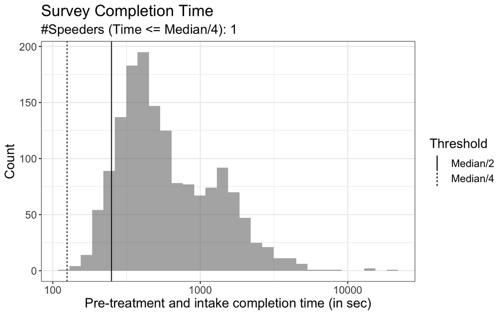

```r
survey_df$pretreatment_intake_time <- survey_df$`Duration (in seconds)` + survey_df$`Duration (in seconds)_pre`
survey_df$speeder <- survey_df$pretreatment_intake_time <= median(survey_df$pretreatment_intake_time)/4 %>%
  replace_na(FALSE)
survey_df %>%
  ggplot() +
  geom_histogram(aes(x = pretreatment_intake_time), alpha = 0.5) +
  scale_x_log10() +
  geom_vline( aes(xintercept = median(pretreatment_intake_time)/2, linetype = 'Median/2')) +
  geom_vline( aes(xintercept = median(pretreatment_intake_time)/4, linetype = 'Median/4')) +
  labs(
    x = 'Pre-treatment and intake completion time (in sec)',
    y = 'Count',
    linetype = 'Threshold',
    title = 'Survey Completion Time',
    subtitle = paste0('#Speeders (Time <= Median/4): ', sum(survey_df$speeder))
  )
```

```r
sum(survey_df$pretreatment_intake_time <= median(survey_df$pretreatment_intake_time)/2)
```

```
## [1] 135
```

## Zip code/state matches

```r
# survey_df$state_from_zip <-
survey_df <- survey_df %>%
  mutate(zip = case_when(
    nchar(zip) == 4 ~ paste0('0', zip),
    .default = zip
  ))


survey_df <- zip_code_db %>%
  select(zipcode, state) %>%
  rename(zip_state = state) %>%
  right_join(survey_df, by = c('zipcode' = 'zip')) %>%
  mutate(
    zip_state =
      case_when(
        zipcode == '77407' ~ "TX",
        zipcode == '85756' ~ "AZ",
        zipcode == '49519' ~ "MI",
        zipcode == "34638" ~ "FL",
        zipcode == "25405" ~ "WV",
        zipcode == "10065" ~ "NY",
        zipcode == "89183" ~ "NV",
        zipcode == "89178" ~ "NV",
        zipcode == "85143" ~ "AZ",
        zipcode == "85140" ~ "AZ",
        zipcode == "32163" ~ "FL",
        zipcode == "85119" ~ "AZ",
        zipcode == "29486" ~ "SC",
        zipcode == "85142" ~ "AZ",
        zipcode == "60169" ~ "IL",
        zipcode == "98391" ~ "WA",
        zipcode == "80923" ~ "CO",
        # https://researchmaniacs.com/ZipCodes/4/Where-is-Zip-Code-46907.html
        zipcode == "46907" ~ "IN",
        zipcode == "10486" ~ "NY",
        zipcode == "91760" ~ "CA",
        zipcode == "00000" ~ NA,
        zipcode == "46343" ~ "IN",
        zipcode == "90289" ~ "CA",
        zipcode == "90268" ~ "CA",
        .default = zip_state)
  ) %>%
  mutate(state_full = get_state_names(zip_state))

survey_df <- survey_df %>%
  mutate(pass_zip_check = (survey_df$state_full == survey_df$state)) %>%
  mutate(pass_zip_check = replace_na(pass_zip_check, replace = FALSE))
```

### Made 1+ post and 1+ comment

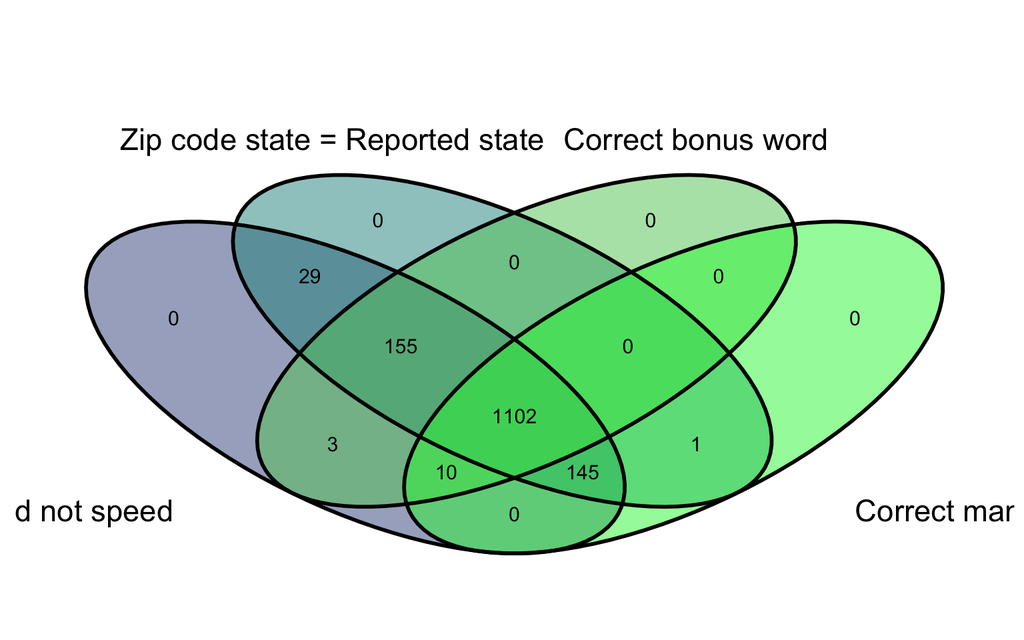

Table continues below

| Did not speed | Zip code state = Reported state | Correct bonus word |
| --- | --- | --- |
| TRUE | TRUE | TRUE |
| TRUE | TRUE | TRUE |
| TRUE | TRUE | FALSE |
| TRUE | TRUE | TRUE |
| TRUE | TRUE | TRUE |
| TRUE | TRUE | TRUE |
| TRUE | TRUE | FALSE |
| TRUE | TRUE | FALSE |
| TRUE | TRUE | TRUE |
| TRUE | TRUE | FALSE |
| TRUE | FALSE | TRUE |
| TRUE | TRUE | FALSE |
| TRUE | FALSE | TRUE |
| TRUE | TRUE | FALSE |
| FALSE | TRUE | FALSE |
| TRUE | FALSE | TRUE |
| TRUE | FALSE | TRUE |

| Pass manip check | Commented | Posted | n |
| --- | --- | --- | --- |
| TRUE | TRUE | TRUE | 868 |
| TRUE | FALSE | TRUE | 129 |
| TRUE | TRUE | TRUE | 110 |
| FALSE | TRUE | TRUE | 105 |
| TRUE | TRUE | FALSE | 105 |
| FALSE | FALSE | TRUE | 32 |
| FALSE | TRUE | TRUE | 22 |
| TRUE | TRUE | FALSE | 22 |
| FALSE | TRUE | FALSE | 18 |
| TRUE | FALSE | TRUE | 13 |
| TRUE | TRUE | TRUE | 8 |
| FALSE | TRUE | FALSE | 4 |
| FALSE | TRUE | TRUE | 3 |
| FALSE | FALSE | TRUE | 3 |
| TRUE | FALSE | TRUE | 1 |
| TRUE | FALSE | TRUE | 1 |
| TRUE | TRUE | FALSE | 1 |

## Demographic/Balance checks

### Age

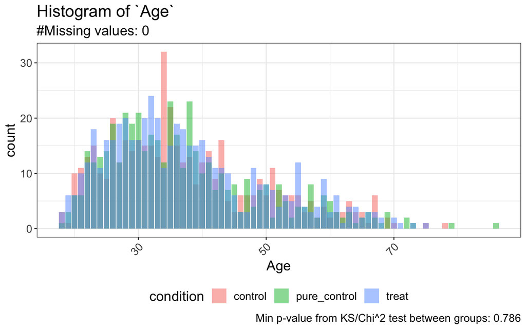

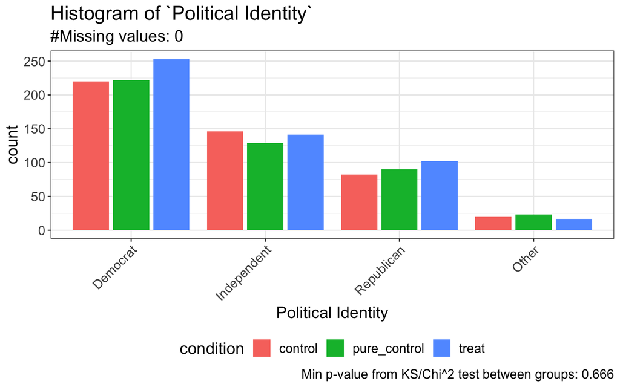

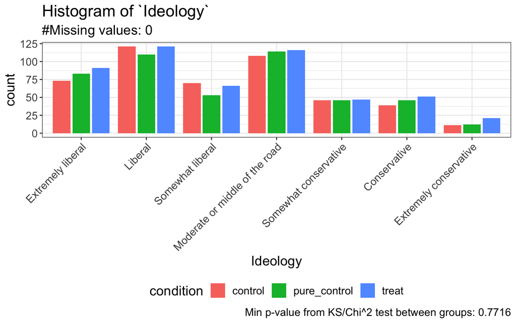

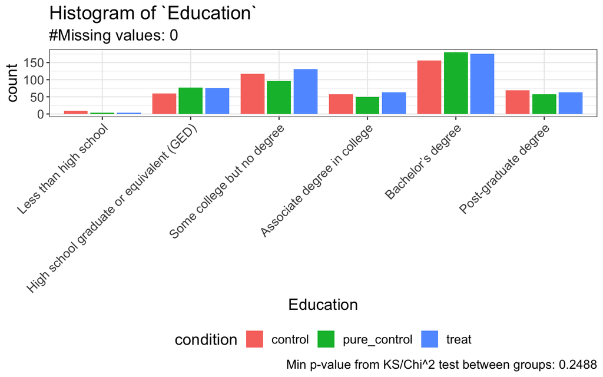

# Main Hypothesis Tests

```r
main_hypothesis_test <- function(df,
                                 outcome,
                                 main_condition = 'treat',
                                 contrast_condition = 'control',
                                 display_plot = FALSE,
                                 title = '',
                                 return_object = FALSE) {
  # isolate data for main group and contrast group
  outcome_main_group <- df %>%
    filter(condition == main_condition) %>%
    .[outcome] %>%
    drop_na() %>%
    pull(.)

  outcome_contrast_group <- df %>%
    filter(condition == contrast_condition) %>%
    .[outcome] %>%
    drop_na() %>%
    pull(.)

  # run t test comparing these two groups
  ttest_results <- t.test(
    x = outcome_main_group,
    y = outcome_contrast_group,
    alternative = 'two.sided',
    var.equal = FALSE
  )
  # ttest_estimate <- ttest_results$
  ttest_pvalue <- ttest_results$p.value
  ttest_cohens_d <- effsize::cohen.d(outcome_main_group,
                                     outcome_contrast_group)$estimate

  # make ttest plot
  n_stars <- ''
  if(ttest_pvalue < 0.05) { n_stars <- '*'}
  else if(ttest_pvalue < 0.01) { n_stars <- '**'}
  else if(ttest_pvalue < 0.001) { n_stars <- '***' }
  p <- ggplot() +
    geom_bar(aes(x = outcome_main_group, y = ..prop.., fill = main_condition), alpha = 0.5, position = 'identity') +
    geom_bar(aes(x = outcome_contrast_group, y = ..prop.., fill = contrast_condition), alpha = 0.5, position = 'identity') +
    geom_density(aes(x = outcome_main_group, fill = main_condition), alpha = 0.5, position = 'identity') +
    geom_density(aes(x = outcome_contrast_group, fill = contrast_condition), alpha = 0.5, position = 'identity') +
    geom_vline(aes(xintercept = mean(outcome_main_group), linetype = main_condition), linewidth = 1) +
    geom_vline(aes(xintercept = mean(outcome_contrast_group), linetype = contrast_condition), linewidth = 1) +
    labs(x = outcome,
         y = 'density',
         title = paste0(title, ': ', outcome, n_stars),
         subtitle = paste0('(p=', round(ttest_pvalue, 3), ', D=', round(ttest_cohens_d, 3), ')'),
         fill = 'Contrast groups',
         linetype = 'Contrast groups'
         )

  if(ttest_pvalue < 0.05) {
    p <- p +
      theme(plot.title = element_text(face = 'bold'),
            plot.subtitle = element_text(face = 'bold'))
  }
return_list <- list('contrast' = paste(main_condition, 'vs', contrast_condition),
                    'ttest' = ttest_results,
                    'p.value' = ttest_pvalue,
                    'cohen.d' = ttest_cohens_d,
                    'plot' = p)
  # if you should display the plot, make the plot and display it
  if(display_plot) print(p)
  if(return_object) return(return_list)
}

subgroup_hypothesis_test <- function(df,
                                 outcome,
                                 subgroup_col,
                                 subgroup_rhs,
                                 main_condition = 'treat',
                                 contrast_condition = 'control',
                                 display_plot = FALSE,
                                 title = '',
                                 return_object = FALSE) {
  result <- main_hypothesis_test(
    df %>% filter(.data[[subgroup_col]] == subgroup_rhs),
    outcome,
    main_condition,
    contrast_condition,
    display_plot,
    title = paste0(title, subgroup_col, '=', subgroup_rhs),
    return_object = TRUE
  )
  if (return_object) return(result)
}

multiple_subgroups_htest <- function(df,
                                 outcome,
                                 subgroup_cols,
                                 subgroup_rhss,
                                 main_condition = 'treat',
                                 contrast_condition = 'control',
                                 display_plot = FALSE,
                                 title = '',
                                 return_object = FALSE)
  {
  row_names <- paste0(subgroup_cols, '=', subgroup_rhss)
  subgroup_results <- data.frame('contrast' = rep(NA, length(row_names)),
                                 'ttest' = rep(NA, length(row_names)),
                                 'p.value' = rep(NA, length(row_names)),
                                 'cohen.d' = rep(NA, length(row_names)),
                                 'plot' = rep(NA, length(row_names)),
                                 row.names = paste0(subgroup_cols, '=', subgroup_rhss))
  for(index in 1:length(subgroup_cols)) {
    sg_result <- subgroup_hypothesis_test(survey_df,
                           outcome = outcome,
                           subgroup_col = subgroup_cols[index],
                           subgroup_rhs = subgroup_rhss[index],
                           display_plot = display_plot,
                           return_object = TRUE)
    subgroup_results[paste0(subgroup_cols[index], '=', subgroup_rhss[index]), ] <- sg_result
  }
  subgroup_results$outcome <- outcome
  subgroup_results$subgroup <- rownames(subgroup_results)
  rownames(subgroup_results) <- NULL
  if(return_object) return(subgroup_results)
}
```

## Hypothesis 1A: experience less negative emotions

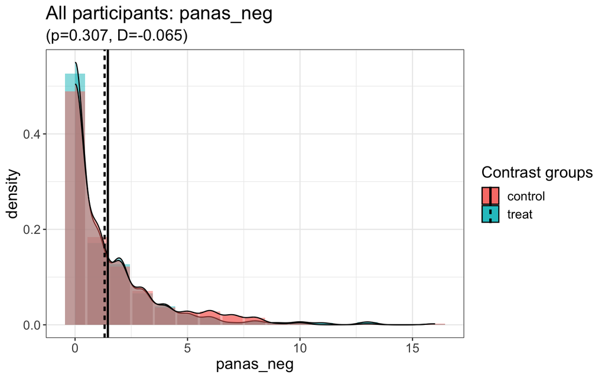

## Hypothesis 1B: experience more positive emotions

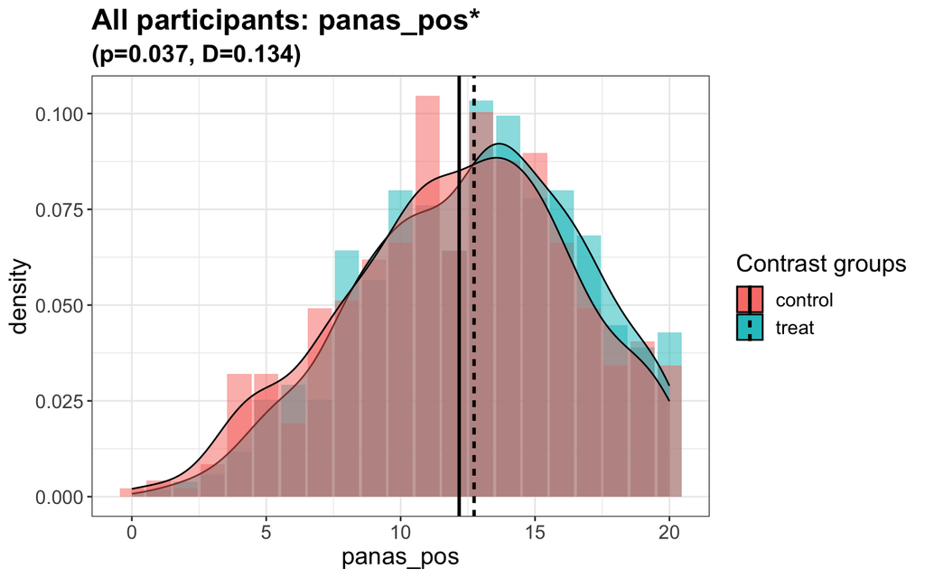

## Hypothesis 1C: experience more positive and less negative emotions

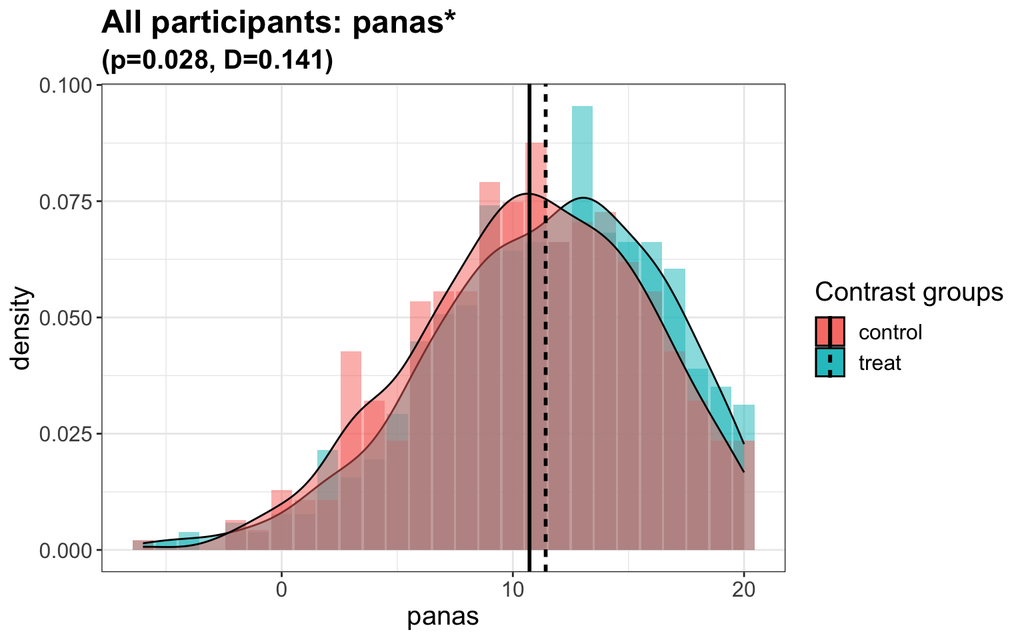

## Hypothesis 2: report greater increases in their intellectual humility

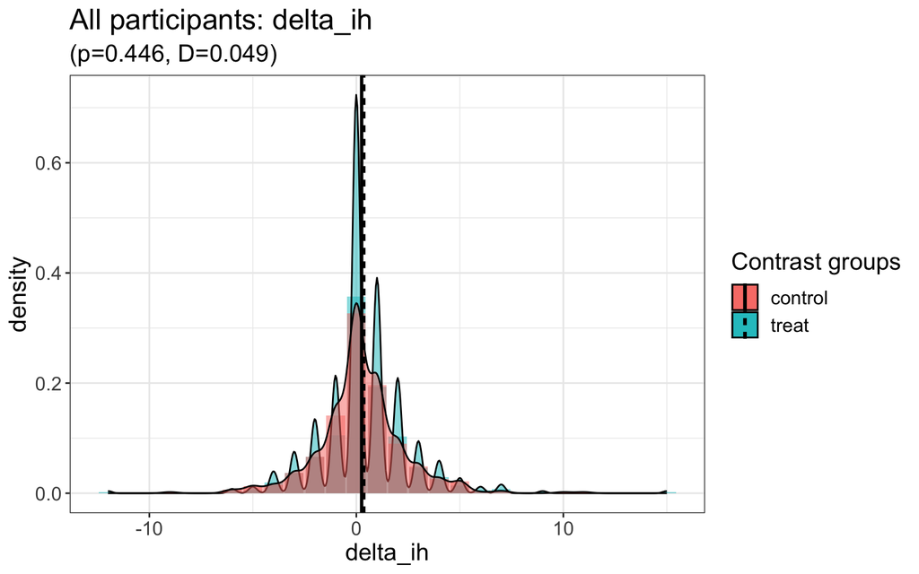

## Hypothesis 3: produce more intellectually humble content

## Hypothesis 4: engage more with intellectually humble content

## Hypothesis 5: experience a greater reduction in their affective polarization

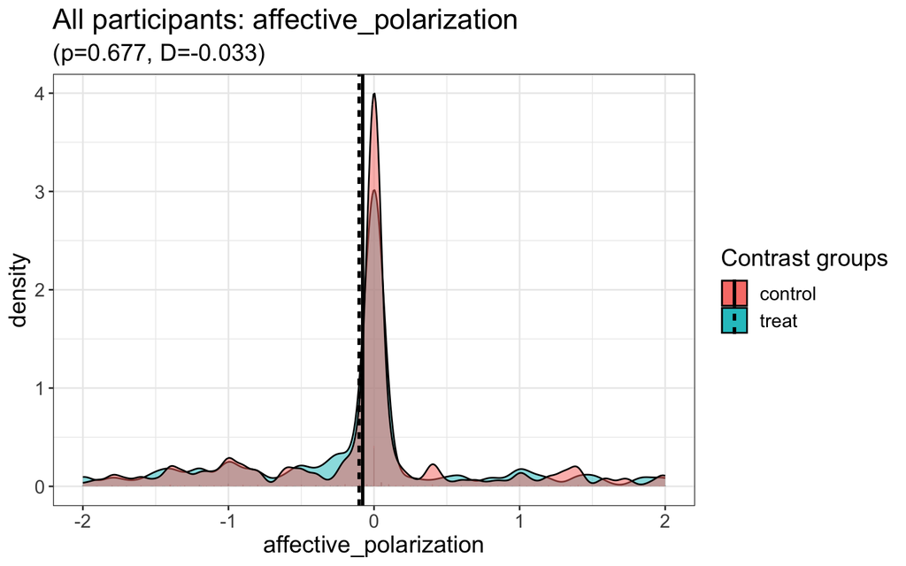

## Hypothesis 6: moderate their issue positions to a greater degree

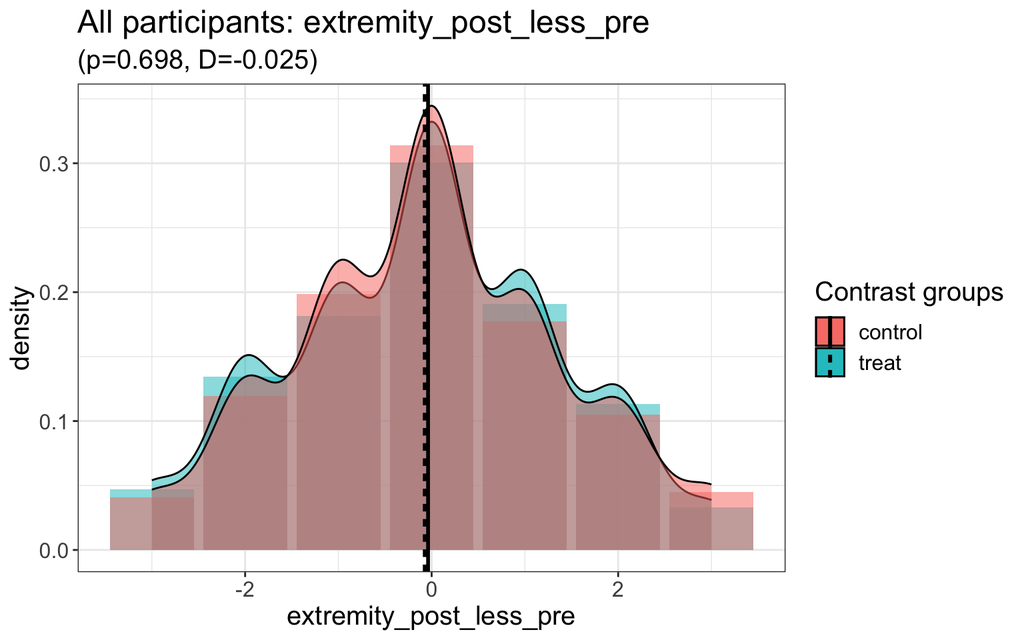

## Subgroup Analyses

```r
subgroup_cols <- c('pre_ih_binary',
                   'pre_ih_binary',
                   'social_media_high',
                   'social_media_high',
                   'pid3',
                   'pid3')
subgroup_rhss <- list(TRUE, FALSE, 1, 0, 'Democrat', 'Republican')

subgroup <- lapply(X = list('panas_neg', 'panas_pos', 'panas', 'delta_ih', 'affective_polarization', 'extremity_post_less_pre'),
       function(x) multiple_subgroups_htest(
  df = survey_df,
  outcome = x,
  subgroup_cols = subgroup_cols,
  subgroup_rhss = subgroup_rhss,
  main_condition = 'treat',
  contrast_condition = 'control',
  display_plot = FALSE,
  title = '',
  return_object = TRUE
)) %>%
  bind_rows()

subgroup %>%
  filter(p.value <= 0.05) %>%
  select(p.value, cohen.d, outcome, subgroup) %>%
  mutate(stars = case_when(
    p.value <= 0.001 ~ '***',
    p.value <= 0.01 ~ '**',
    p.value <= 0.05 ~ '*'
  )) %>%
  mutate(cohen.d = paste0(round(cohen.d, 3), stars)) %>%
  pivot_wider(id_cols = 'subgroup', names_from = 'outcome', values_from = 'cohen.d') %>%
  column_to_rownames('subgroup') %>%
  pander::pander(caption = 'Rows represent subgroups, columns represent outcome, and entries represent effect size. p<0.05*, p<0.01**, p<0.001***')
```

Rows represent subgroups, columns represent outcome, and entries represent effect size. p<0.05*, p<0.01**, p<0.001***

|  | panas_neg | panas_pos | panas |
| --- | --- | --- | --- |
| **social_media_high=1** | -0.236** | NA | 0.233** |
| **pre_ih_binary=FALSE** | NA | 0.223** | 0.229** |
| **pid3=Republican** | NA | 0.342* | 0.391* |

## Other Questions

### How do descriptions of the platform differ between treated and control users?

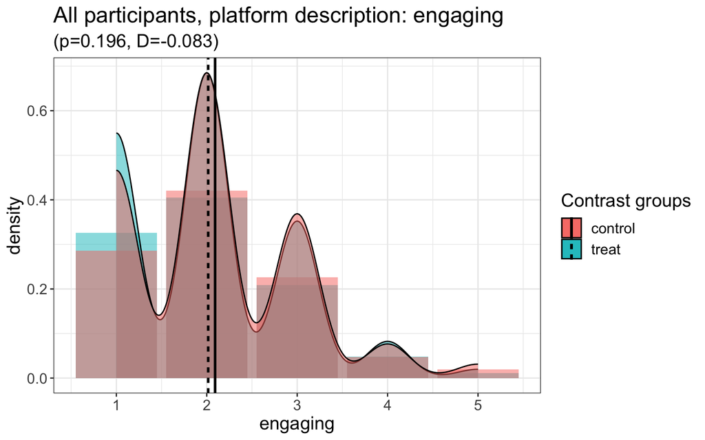

```r
main_hypothesis_test(survey_df, 'engaging', display_plot = TRUE, title = 'All participants, platform description')
```

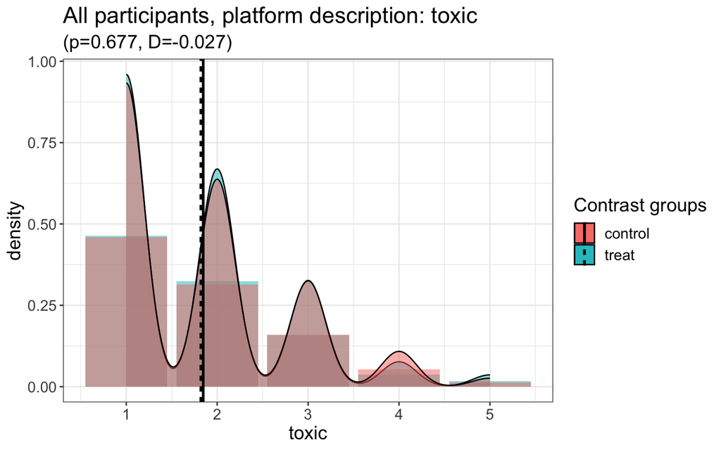

```r
main_hypothesis_test(survey_df, 'toxic', display_plot = TRUE, title = 'All participants, platform description')
```

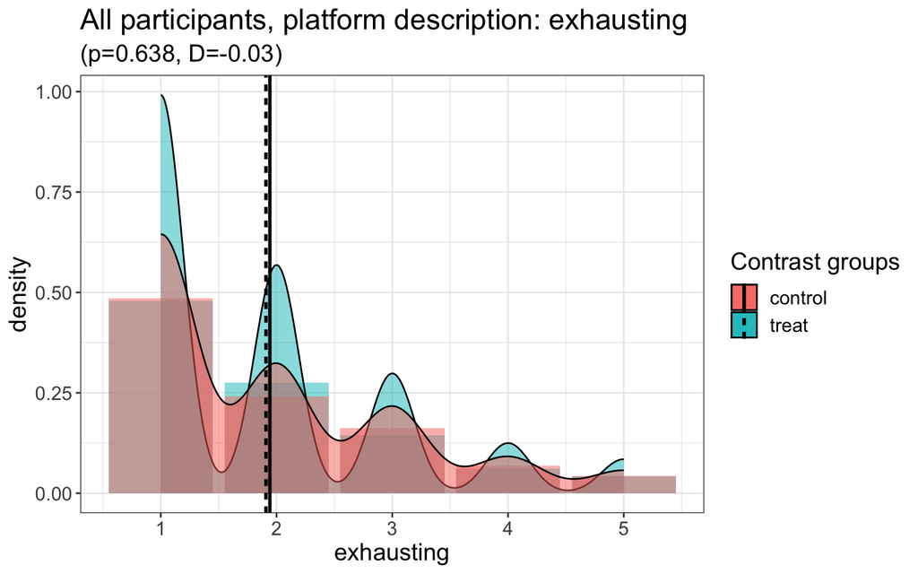

```r
main_hypothesis_test(survey_df, 'exhausting', display_plot = TRUE, title = 'All participants, platform description')
```

### How do descriptions of other users differ between treated and control users?

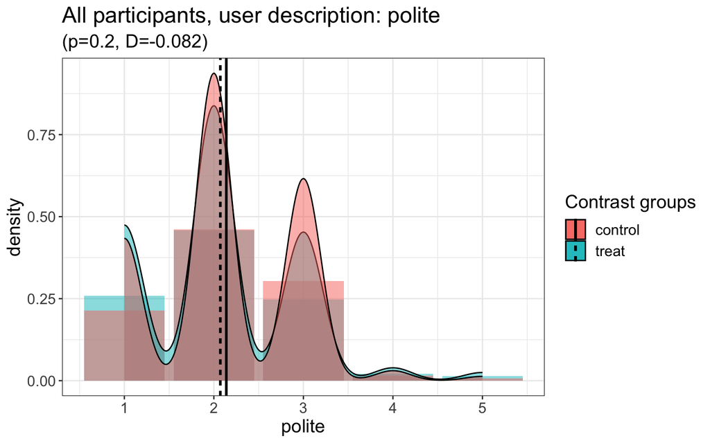

```r
main_hypothesis_test(survey_df, 'polite', display_plot = TRUE, title = 'All participants, user description')
```

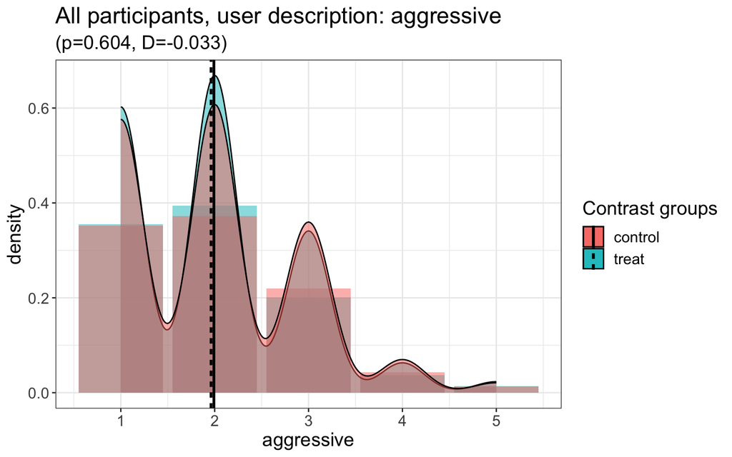

```r
main_hypothesis_test(survey_df, 'aggressive', display_plot = TRUE, title = 'All participants, user description')
```

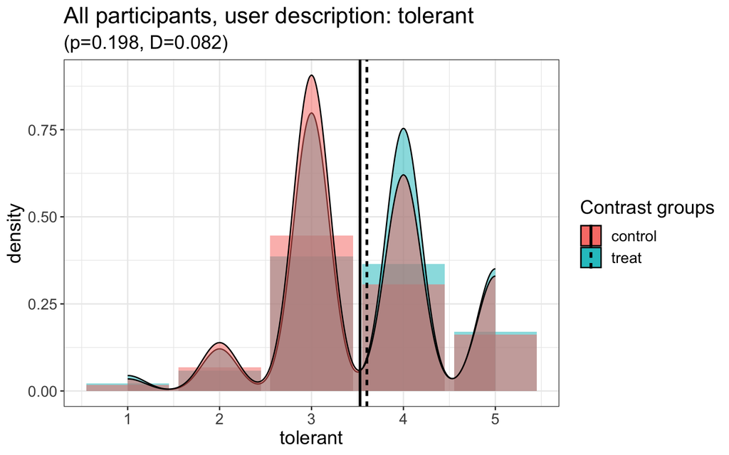

```r
main_hypothesis_test(survey_df, 'tolerant', display_plot = TRUE, title = 'All participants, user description')
```

### How does treatment affect comfort in sharing ideas?

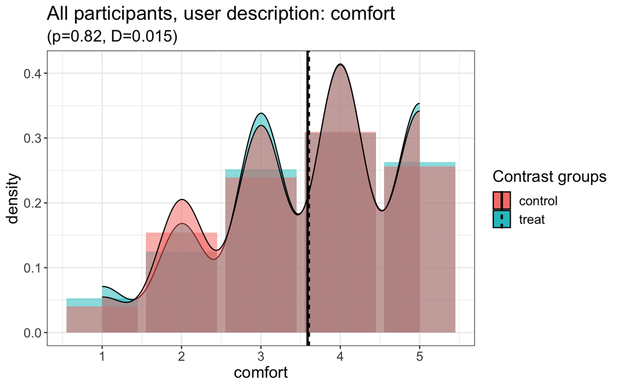

```r
main_hypothesis_test(survey_df, 'comfort', display_plot = TRUE, title = 'All participants, user description')
```

### Estimation of bots

```r
survey_df %>%
  group_by(bots) %>%
  count() %>%
  ungroup() %>%
  mutate(prop = round(n/sum(n), 3))
```

```
## # A tibble: 4 × 3
##   bots                                   n  prop
##   <chr>                              <int> <dbl>
## 1 No, I did not encounter any bots     651 0.451
## 2 Yes, I encountered many bots         150 0.104
## 3 Yes, I encountered one or two bots   463 0.32
## 4 Yes, I encountered several bots      181 0.125
```

### How does treatment affect engagement with the platform?

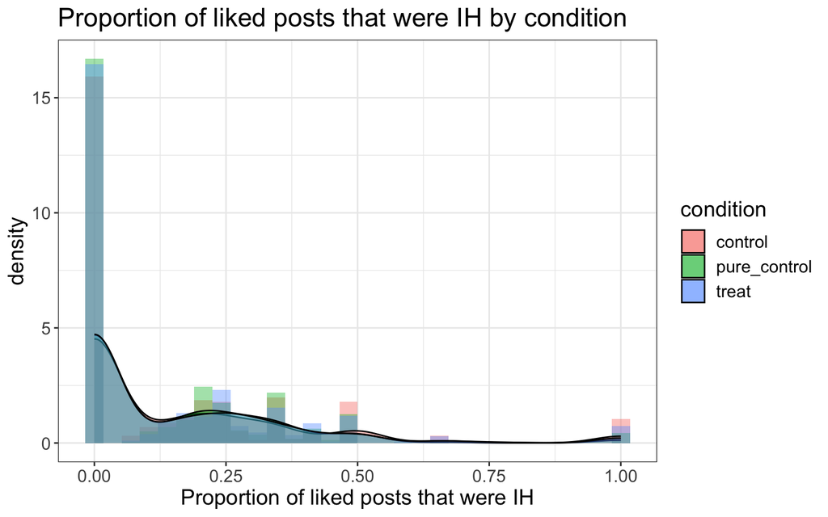

```r
ggplot(survey_df) +
  geom_histogram(aes(x = p_likes_ih, y = ..density.., fill = condition), position = 'identity', alpha = 0.4) +
  geom_density(aes(x = p_likes_ih, fill = condition), position = 'identity', alpha = 0.4) +
  labs(x = 'Proportion of liked posts that were IH',
       title = 'Proportion of liked posts that were IH by condition')
```

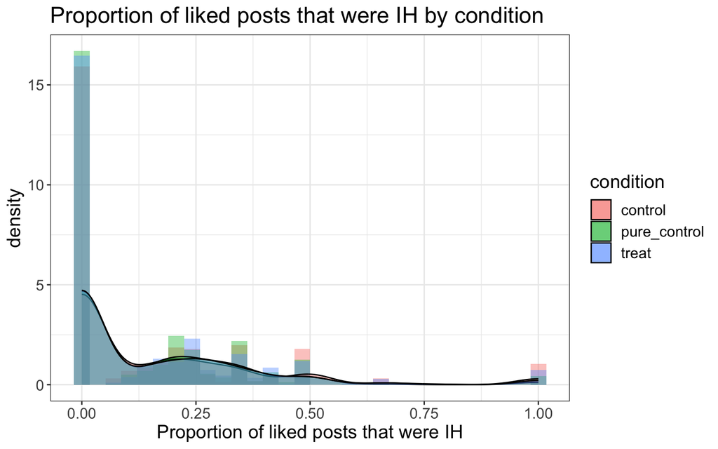

```r
ggplot(survey_df) +
  geom_histogram(aes(x = p_likes_ih, y = ..density.., fill = condition), position = 'identity', alpha = 0.4) +
  geom_density(aes(x = p_likes_ih, fill = condition), position = 'identity', alpha = 0.4) +
  labs(x = 'Proportion of liked posts that were IH',
       title = 'Proportion of liked posts that were IH by condition')
```

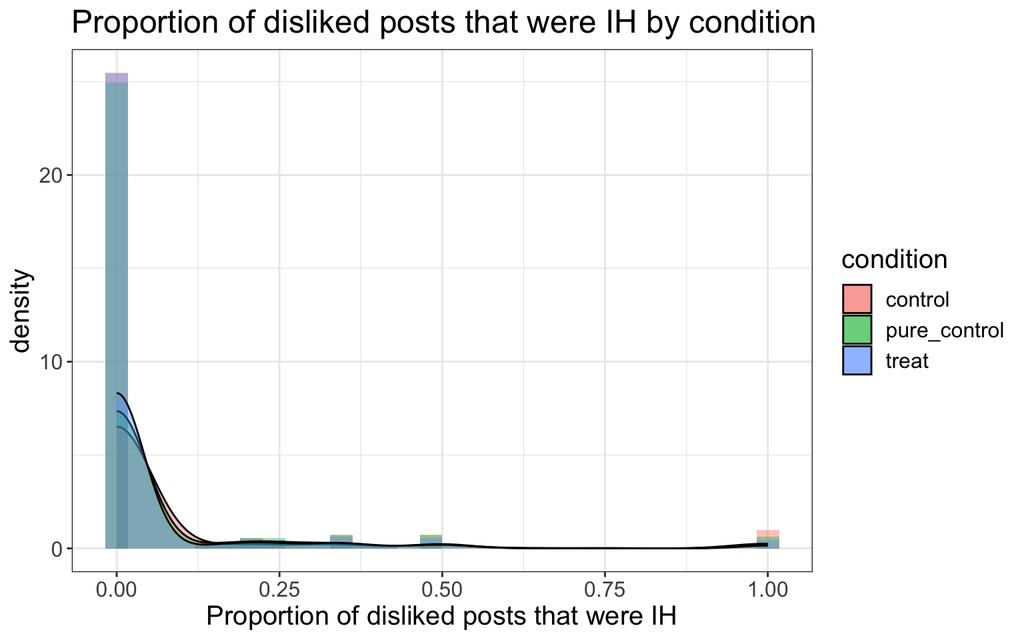

```r
ggplot(survey_df) +
  geom_histogram(aes(x = p_dislikes_ih, y = ..density.., fill = condition), position = 'identity', alpha = 0.4) +
  geom_density(aes(x = p_dislikes_ih, fill = condition), position = 'identity', alpha = 0.4) +
  labs(x = 'Proportion of disliked posts that were IH',
       title = 'Proportion of disliked posts that were IH by condition')
```

### How does dwell time relate to outcome measures?

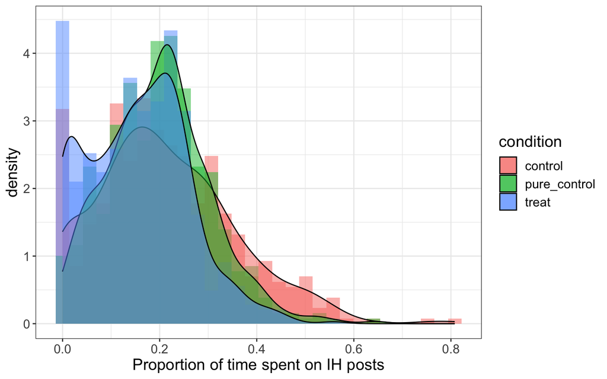

```r
ggplot(survey_df) +
  geom_histogram(aes(x = prop_dwell_time_ih, y = ..density.., fill = condition), alpha = 0.5, position =  'identity') +
  geom_density(aes(x = prop_dwell_time_ih, fill = condition), alpha = 0.5, position = 'identity') +
  labs(x = 'Proportion of time spent on IH posts')
```

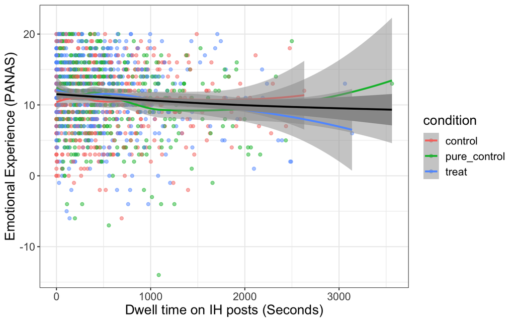

```r
ggplot(survey_df) +
  geom_point(aes(x = ih_dwell_time, y = panas, color = condition), alpha = 0.5) +
  geom_smooth(aes(x = ih_dwell_time, y = panas, color = condition), alpha = 0.5) +
  geom_smooth(aes(x = ih_dwell_time, y = panas), alpha = 1, color = 'black') +
  labs(x = 'Dwell time on IH posts (Seconds)',
       y = 'Emotional Experience (PANAS)')
```

```r
survey_df %>%
  select(
    ih_dwell_time,
    panas,
    # third_order,
    delta_ih,
    # future_use_n,
    engaging,
    toxic,
    exhausting,
    platforms,
    polite,
    aggressive,
    tolerant,
    users,
    users_b,
    comfort
  ) %>%
  pivot_longer(cols = -ih_dwell_time) %>%
  group_by(name) %>%
  summarize(pearson_p = cor.test(ih_dwell_time, value, method = 'pearson')$p.value %>% round(., 3),
            pearson = cor.test(ih_dwell_time, value, method = 'pearson')$estimate  %>% round(., 3),
            spearman_p = cor.test(ih_dwell_time, value, method = 'spearman')$p.value %>% round(., 3),
            spearman = cor.test(ih_dwell_time, value, method = 'spearman')$estimate  %>% round(., 3)) %>% pander::pander()
```

| name | pearson_p | pearson | spearman_p | spearman |
| --- | --- | --- | --- | --- |
| aggressive | 0.292 | -0.028 | 0.603 | -0.014 |
| comfort | 0 | -0.135 | 0 | -0.135 |
| delta_ih | 0.697 | -0.01 | 0.319 | -0.026 |
| engaging | 0 | 0.094 | 0.003 | 0.078 |
| exhausting | 0.508 | 0.017 | 0.832 | -0.006 |
| panas | 0.001 | -0.09 | 0.002 | -0.08 |
| platforms | 0.068 | 0.048 | 0.274 | 0.029 |
| polite | 0.044 | 0.053 | 0.081 | 0.046 |
| tolerant | 0.289 | -0.028 | 0.335 | -0.025 |
| toxic | 0.658 | 0.012 | 0.419 | 0.021 |
| users | 0.819 | -0.006 | 0.92 | 0.003 |
| users_b | 0.358 | 0.024 | 0.555 | 0.016 |

# Heterogeneous treatment effects using BART: Installation issues. Can’t do `BCF` now

```r
library(dbarts)
library(fastDummies)
library(janitor)

outcome_cols <- c('panas', 'panas_pos', 'panas_neg', 'delta_ih', 'affective_polarization', 'extremity_post_less_pre', 'third_order')

cate_survey_df_original_names <- survey_df %>%
  select(all_of(c(demog_cols, pretreat_cols, outcome_cols, 'condition'))) %>%
    drop_na()
cate_survey_df <- cate_survey_df_original_names %>%
  fastDummies::dummy_columns(select_columns = c(demog_cols, pretreat_cols),
                             remove_selected_columns = TRUE) %>%
  janitor::clean_names()



tlearner_bart <- function(x.train_treat, y.train_treat, x.train_control, y.train_control, x.test) {
  bart_treat <- dbarts::bart(x.train = x.train_treat,
                             y.train = y.train_treat,
                             keeptrees = TRUE,
                             verbose = FALSE)
  bart_control <- dbarts::bart(x.train = x.train_control,
                               y.train = y.train_control,
                               keeptrees = TRUE,
                               verbose = FALSE)
  y1 <- predict(bart_treat, x.test)
  y0 <- predict(bart_control, x.test)
  return_obj <- list('bart_treat' = bart_treat,
                     'bart_control' = bart_control,
                     cate = y1 - y0)
  return(colMeans(y1) - colMeans(y0))
}

cate_estimates <- sapply(c('panas', 'panas_neg', 'panas_pos', 'third_order'),
       function(x) {
         print(x)
         y <- tlearner_bart(x.train_treat = cate_survey_df %>%
                            filter(condition == 'treat') %>%
                            select(-outcome_cols) %>%
                            select(-condition),
                            y.train_treat = cate_survey_df %>%
                              filter(condition == 'treat') %>%
                              .[[x]],
                            x.train_control = cate_survey_df %>%
                            filter(condition == 'control') %>%
                            select(-outcome_cols) %>%
                              select(-condition),
                            y.train_control = cate_survey_df %>%
                              filter(condition == 'control') %>%
                              .[[x]],
                            x.test = cate_survey_df %>%
                              filter(condition != 'pure_control')
         )
         return(y)
       }
       )
```

```
## [1] "panas"
## [1] "panas_neg"
## [1] "panas_pos"
## [1] "third_order"
```

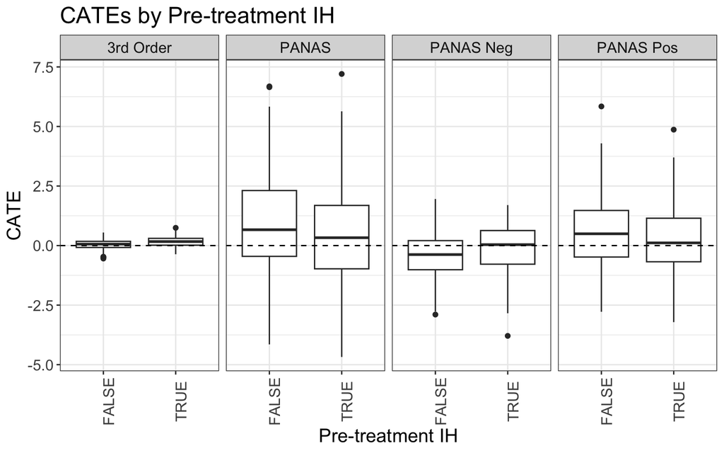

[output not shown]

```r
cate_estimates_tbl <- cate_estimates %>%
  as_tibble() %>%
  rename(PANAS = panas,
        `PANAS Neg` = panas_neg,
        `PANAS Pos` = panas_pos,
        `3rd Order` = third_order)

cate_full_df <- cate_survey_df_original_names %>%
  filter(condition != 'pure_control') %>%
  bind_cols(cate_estimates_tbl)


cate_plot <- function(cate_df, conditional, fill_label) {
  p <- cate_df %>%
  pivot_longer(cols = colnames(cate_estimates_tbl)) %>%
  ggplot(.) +
  geom_boxplot(aes(x = !!as.symbol(conditional), y = value)) +
  facet_grid(.~name, scales = 'free_y') +
    labs(y = 'CATE',
         x = fill_label,
         title = paste0('CATEs by ', fill_label)) +
    geom_hline(yintercept = 0, linetype = 'dashed') +
    theme(axis.text.x = element_text(angle = 90))
  print(p)

  cate_df %>%
    group_by(!!as.symbol(conditional)) %>%
    summarise_at(.vars = colnames(cate_estimates_tbl), .funs = mean) %>%
    pander::pander(caption = paste0('CATEs by subgroup: ', fill_label))
}
```

CATEs by subgroup: Pre-treatment IH

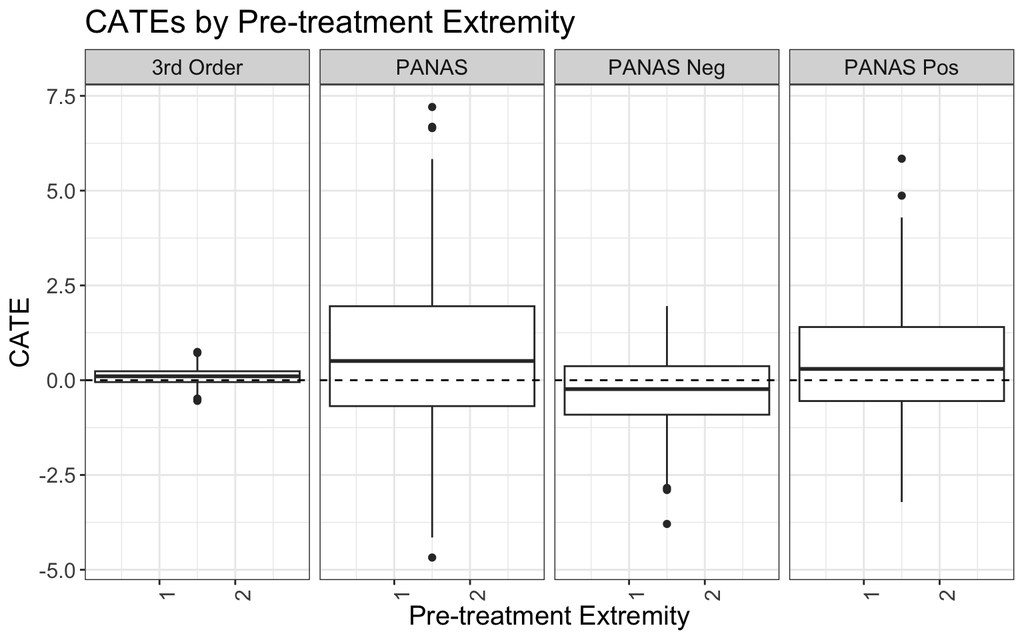

extremity_pre PANAS PANAS Neg PANAS Pos 3rd Order

```
   0         1.872     -0.9941     0.8841      0.1026

   1         1.424     -0.3651      1.075      0.1392

   2         0.4179    -0.1823      0.265      0.05335

   3         0.1221    -0.1248    0.007867     0.1003
```

CATEs by subgroup: Pre-treatment Extremity

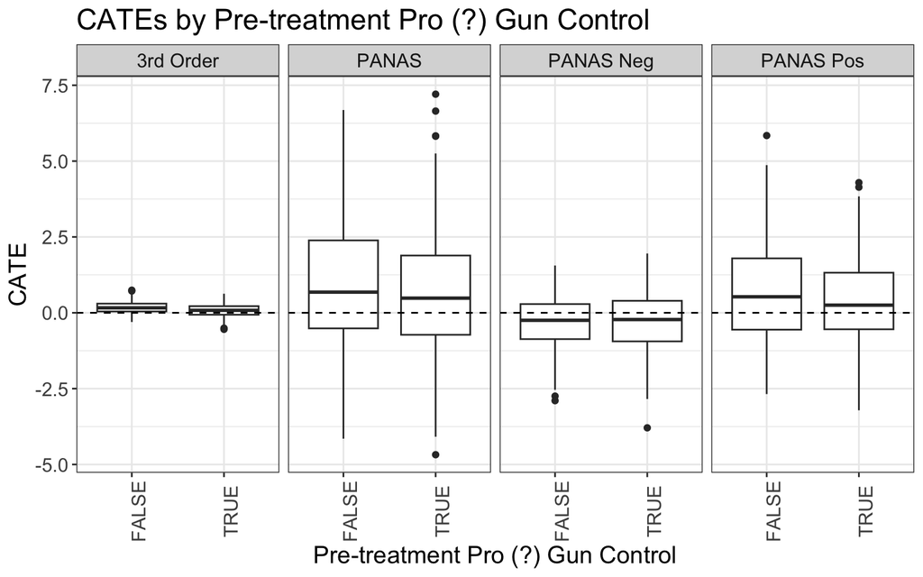

pre_policy_gc_binary PANAS PANAS Neg PANAS Pos 3rd Order

```
    FALSE           0.9133    -0.2963     0.6559      0.1647

     TRUE           0.5945    -0.2701     0.3342      0.07685
```

CATEs by subgroup: Pre-treatment Pro (?) Gun Control

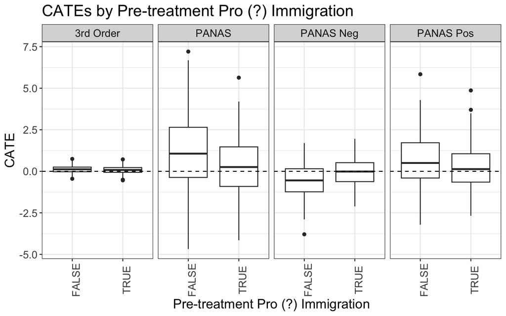

pre_policy_imm_binary PANAS PANAS Neg PANAS Pos 3rd Order

```
     FALSE           1.166     -0.5542     0.6288       0.118

     TRUE            0.2682   -0.05356     0.2308      0.08005
```

CATEs by subgroup: Pre-treatment Pro (?) Immigration

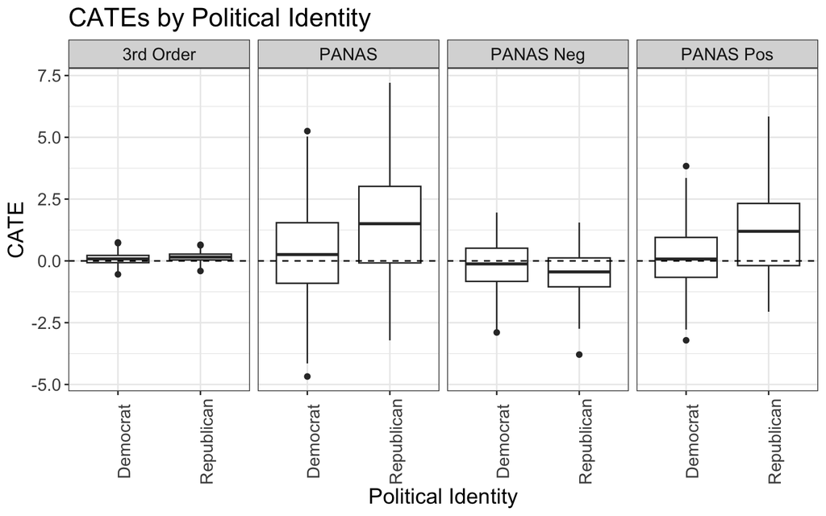

pid3 PANAS PANAS Neg PANAS Pos 3rd Order

Democrat 0.3084 -0.1963 0.124 0.07664

## Republican 1.59 -0.4812 1.137 0.149

CATEs by subgroup: Political Identity

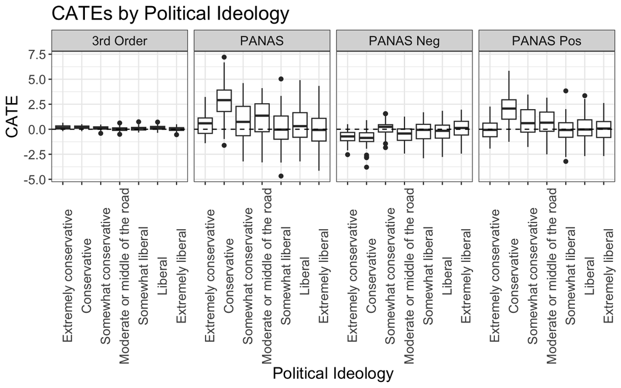

ideo7 PANAS PANAS Neg PANAS Pos 3rd Order

```
 Extremely conservative        0.502      -0.7813     -0.062      0.1634

      Conservative             2.863      -0.8888      1.974      0.1878

 Somewhat conservative         0.7139     0.1287       0.77       0.1111
```

Moderate or middle of the road 1.121 -0.5225 0.6919 -0.009429

```
    Somewhat liberal           0.1129     -0.2173    -0.08133     0.07619

        Liberal                0.3928     -0.2689     0.1319      0.1408

   Extremely liberal          -0.06967    0.07619    0.003423    0.009766
```

Table: CATEs by subgroup: Political Ideology